# Predicting Steam Game Success

## Spring 2024 Data Science Project

Member 1: Alex Barker, Contribution: 100%

Member 2: Christopher Clark, Contribution: 100%

Member 3: Srivishnu Piratla, Contribution: 100%

We, all team members, agree together that the above information is true, and we are confident about our contributions to this submitted project/final tutorial. - Alex Barker, Christopher Clark, Srivishnu Piratla 5/7/2024

Member 1: Alex Barker - We did each part as a team. This included all parts A-H.

Member 2: Christopher Clark - We did each part as a team. This included all parts A-H.

Member 3: Srivishnu Piratla - We did each part as a team. This included all parts A-H.

Part H: We ended up setting up an instance on AWS using EC2 to have ennough compute to handle the data.

## Introduction

**Video games have emerged as a new form of entertainment, with PC games being particularly popular. Steam, one of the most successful PC game distributors, provides public game metrics openly, including genre, publisher, and price. We want to analyze this data to see if there are specific factors that have a large impact on game sales.**

**Since video games are unique experiences, many believe that a game's success is independent of external features such as category or ratings. We plan to either validate or refute this claim by analyzing the accuracy of a predictive model.**

**This tutorial will guide you through the various steps and methodologies required to analyze a dataset. In particular, we will walk through data preprocessing, data cleaning, summary statistics, and using a machine learning model to capture potential relationships. Given metadata about a potential game, our model aims to predict its level of success as measured by how many copies are sold.**

**In particular, it will be interesting to see whether our model can verify the general idea that gameplay determines a game's success the most by failing to find important relationships. This would mean success is not tied to metadata. However, it may also fail to disprove our intuition by being very accurate, meaning relationships were found.**

**We also would like our model to highlight what it deems to be the most important factor in determining a games' success.**

## Data Curation

**We took a [Steam game dataset](https://www.kaggle.com/datasets/nikdavis/steam-store-games/data) that already scraped data from the Steam and SteamSpy APIs. SteamSpy is a site that tracks and analyzes Steam sales, so we will train our model on estimates since Steam doesn't release the exact number of sales a game has.**

**First, we import all of the libraries we plan on using.**

**For ease of access, we will import the CSV as a Pandas DataFrame, and operate on that.**

```python
# import necessary modules

import pandas as pd
import numpy as np
from collections import Counter
import matplotlib.pyplot as plt
import scipy
import sys
import re
from sklearn.metrics import accuracy_score, classification_report, confusion_matrix
from sklearn.model_selection import KFold, train_test_split
from sklearn.preprocessing import StandardScaler
from sklearn.compose import ColumnTransformer
from matplotlib.colors import ListedColormap
import lightgbm as lgb
import seaborn as ses
```

```python
# read in the dataset using Pandas
df = pd.read_csv("steam.csv")
df
```

|  | appid | name | release_date | english | developer | publisher | platforms | required_age | categories | genres | steamspy_tags | achievements | positive_ratings | negative_ratings | average_playtime | median_playtime | owners | price |
| --- | --- | --- | --- | --- | --- | --- | --- | --- | --- | --- | --- | --- | --- | --- | --- | --- | --- | --- |
| 0 | 10 | Counter-Strike | 11/1/00 | 1 | Valve | Valve | windows;mac;linux | 0 | Multi-player;Online Multi-Player;Local Multi-P... | Action | Action;FPS;Multiplayer | 0 | 124534 | 3339 | 17612 | 317 | 10000000-20000000 | 7.19 |
| 1 | 20 | Team Fortress Classic | 4/1/99 | 1 | Valve | Valve | windows;mac;linux | 0 | Multi-player;Online Multi-Player;Local Multi-P... | Action | Action;FPS;Multiplayer | 0 | 3318 | 633 | 277 | 62 | 5000000-10000000 | 3.99 |
| 2 | 30 | Day of Defeat | 5/1/03 | 1 | Valve | Valve | windows;mac;linux | 0 | Multi-player;Valve Anti-Cheat enabled | Action | FPS;World War II;Multiplayer | 0 | 3416 | 398 | 187 | 34 | 5000000-10000000 | 3.99 |
| 3 | 40 | Deathmatch Classic | 6/1/01 | 1 | Valve | Valve | windows;mac;linux | 0 | Multi-player;Online Multi-Player;Local Multi-P... | Action | Action;FPS;Multiplayer | 0 | 1273 | 267 | 258 | 184 | 5000000-10000000 | 3.99 |
| 4 | 50 | Half-Life: Opposing Force | 11/1/99 | 1 | Gearbox Software | Valve | windows;mac;linux | 0 | Single-player;Multi-player;Valve Anti-Cheat en... | Action | FPS;Action;Sci-fi | 0 | 5250 | 288 | 624 | 415 | 5000000-10000000 | 3.99 |
| ... | ... | ... | ... | ... | ... | ... | ... | ... | ... | ... | ... | ... | ... | ... | ... | ... | ... | ... |
| 27069 | 1065230 | Room of Pandora | 4/24/19 | 1 | SHEN JIAWEI | SHEN JIAWEI | windows | 0 | Single-player;Steam Achievements | Adventure;Casual;Indie | Adventure;Indie;Casual | 7 | 3 | 0 | 0 | 0 | 0-20000 | 2.09 |
| 27070 | 1065570 | Cyber Gun | 4/23/19 | 1 | Semyon Maximov | BekkerDev Studio | windows | 0 | Single-player | Action;Adventure;Indie | Action;Indie;Adventure | 0 | 8 | 1 | 0 | 0 | 0-20000 | 1.69 |
| 27071 | 1065650 | Super Star Blast | 4/24/19 | 1 | EntwicklerX | EntwicklerX | windows | 0 | Single-player;Multi-player;Co-op;Shared/Split ... | Action;Casual;Indie | Action;Indie;Casual | 24 | 0 | 1 | 0 | 0 | 0-20000 | 3.99 |
| 27072 | 1066700 | New Yankee 7: Deer Hunters | 4/17/19 | 1 | Yustas Game Studio | Alawar Entertainment | windows;mac | 0 | Single-player;Steam Cloud | Adventure;Casual;Indie | Indie;Casual;Adventure | 0 | 2 | 0 | 0 | 0 | 0-20000 | 5.19 |
| 27073 | 1069460 | Rune Lord | 4/24/19 | 1 | Adept Studios GD | Alawar Entertainment | windows;mac | 0 | Single-player;Steam Cloud | Adventure;Casual;Indie | Indie;Casual;Adventure | 0 | 4 | 0 | 0 | 0 | 0-20000 | 5.19 |

27074 rows × 18 columns

**Let's look at each feature's datatype to see if we need to change any.**

```python
df.dtypes
```

```
appid                 int64
name                 object
release_date         object
english               int64
developer            object
publisher            object
platforms            object
required_age          int64
categories           object
genres               object
steamspy_tags        object
achievements          int64
positive_ratings      int64
negative_ratings      int64
average_playtime      int64
median_playtime       int64
owners               object
price               float64
dtype: object
```

**It looks like the release date is type `object` instead of type `datetime`. Let's fix that. While we're at it, the "owners" column name is unintuitive, at least for our purposes. We can change that to "sales" since we want to predict.**

```python
# convert release_date to type datetime
df['release_date'] = pd.to_datetime(df['release_date'], format='%m/%d/%y')

# rename "owners" to "sales"
df.rename({'owners': 'sales'}, axis=1, inplace=True)
```

**Let's take a preliminary look at the data to see how clean the dataset is.**

```python
print("English value distributions: {}".format(df['english'].value_counts()))
print("Required age distribution: {}".format(df['required_age'].value_counts()))
print("Achievement count distribution: {}".format(df['achievements'].value_counts()))
```

```
English value distributions: english
1    26563
0      511
Name: count, dtype: int64
Required age distribution: required_age
0     26478
18      308
16      192
12       73
7        12
3        11
Name: count, dtype: int64
Achievement count distribution: achievements
0       11864
10        679
12        618
20        574
15        490
        ...
5394        1
678         1
2130        1
225         1
233         1
Name: count, Length: 410, dtype: int64
```

```python
df = df.drop(columns=["appid", "english", "required_age", "genres", "achievements", "name"])
```

**We also have several semicolon-separated lists in our dataset, namely the "steamspy_tags", "categories", and "platforms" columns. It will be easier to handle them as lists, so we'll go ahead and convert them. The sales column also can be converted to a list of min-max.**

```python
# convert sales to a list of min-max
df['sales'] = df['sales'].apply(lambda x: x.split("-"))

# convert steamspy tags to a list
df["steamspy_tags"] = df["steamspy_tags"].apply(lambda x: x.split(";"))

# convert categories to a list
df["categories"] = df["categories"].apply(lambda x: x.split(";"))

# convert platforms to a list and capitalize the first letter of each element
def convert_platforms(entry):
    entry_list = entry.split(";")
    return [e.capitalize() for e in entry_list]

df["platforms"] = df["platforms"].apply(convert_platforms)
```

**Depending on a game's popularity, it may have more or less reviews than other games. There is no "total ratings" column, so let's add that. Additionally, to better see the ratio between positive and negative reviews, let's calculate that and put it into a "positive rating proportion" column.**

```python
# calculate total ratings
df["total_ratings"] = df["positive_ratings"] + df["negative_ratings"]

# calculate positive rating proportion by dividing positive ratings over the total number of ratings
df["pos_rating_proportion"] = df['positive_ratings']/(df['negative_ratings']+df['positive_ratings'])
df['pos_rating_proportion_categories'] = df["pos_rating_proportion"].apply(lambda x: str( ((x//0.1)*10)) + "% to " + str((x//0.1)*10+10) + "%" )
```

**Since the number of sales is a range, let's create "maximum sales" and "minimum sales" columns so we can work with the numbers.**

```python
df["minimum_sales"] = df["sales"].apply(lambda x: int(x[0]))
df["maximum_sales"] = df["sales"].apply(lambda x: int(x[1]))
```

**We will also make a copy of our dataframe, so we have an unchanged original copy and a new copy in which we can perform transformations on. This is nice, as we will perform many different transformations for our ML model that can appear cluttered.**

```python
# make a copy of df for the model, since it's easier to do data analysis on a list but one-hot encode for a model
df2 = df.copy(deep=True)
```

**Now let's see what our dataframe looks like before performing any data analysis.**

```python
df2
```

|  | release_date | developer | publisher | platforms | categories | steamspy_tags | positive_ratings | negative_ratings | average_playtime | median_playtime | sales | price | total_ratings | pos_rating_proportion | pos_rating_proportion_categories | minimum_sales | maximum_sales |
| --- | --- | --- | --- | --- | --- | --- | --- | --- | --- | --- | --- | --- | --- | --- | --- | --- | --- |
| 0 | 2000-11-01 | Valve | Valve | [Windows, Mac, Linux] | [Multi-player, Online Multi-Player, Local Mult... | [Action, FPS, Multiplayer] | 124534 | 3339 | 17612 | 317 | [10000000, 20000000] | 7.19 | 127873 | 0.973888 | 90.0% to 100.0% | 10000000 | 20000000 |
| 1 | 1999-04-01 | Valve | Valve | [Windows, Mac, Linux] | [Multi-player, Online Multi-Player, Local Mult... | [Action, FPS, Multiplayer] | 3318 | 633 | 277 | 62 | [5000000, 10000000] | 3.99 | 3951 | 0.839787 | 80.0% to 90.0% | 5000000 | 10000000 |
| 2 | 2003-05-01 | Valve | Valve | [Windows, Mac, Linux] | [Multi-player, Valve Anti-Cheat enabled] | [FPS, World War II, Multiplayer] | 3416 | 398 | 187 | 34 | [5000000, 10000000] | 3.99 | 3814 | 0.895648 | 80.0% to 90.0% | 5000000 | 10000000 |
| 3 | 2001-06-01 | Valve | Valve | [Windows, Mac, Linux] | [Multi-player, Online Multi-Player, Local Mult... | [Action, FPS, Multiplayer] | 1273 | 267 | 258 | 184 | [5000000, 10000000] | 3.99 | 1540 | 0.826623 | 80.0% to 90.0% | 5000000 | 10000000 |
| 4 | 1999-11-01 | Gearbox Software | Valve | [Windows, Mac, Linux] | [Single-player, Multi-player, Valve Anti-Cheat... | [FPS, Action, Sci-fi] | 5250 | 288 | 624 | 415 | [5000000, 10000000] | 3.99 | 5538 | 0.947996 | 90.0% to 100.0% | 5000000 | 10000000 |
| ... | ... | ... | ... | ... | ... | ... | ... | ... | ... | ... | ... | ... | ... | ... | ... | ... | ... |
| 27069 | 2019-04-24 | SHEN JIAWEI | SHEN JIAWEI | [Windows] | [Single-player, Steam Achievements] | [Adventure, Indie, Casual] | 3 | 0 | 0 | 0 | [0, 20000] | 2.09 | 3 | 1.000000 | 90.0% to 100.0% | 0 | 20000 |
| 27070 | 2019-04-23 | Semyon Maximov | BekkerDev Studio | [Windows] | [Single-player] | [Action, Indie, Adventure] | 8 | 1 | 0 | 0 | [0, 20000] | 1.69 | 9 | 0.888889 | 80.0% to 90.0% | 0 | 20000 |
| 27071 | 2019-04-24 | EntwicklerX | EntwicklerX | [Windows] | [Single-player, Multi-player, Co-op, Shared/Sp... | [Action, Indie, Casual] | 0 | 1 | 0 | 0 | [0, 20000] | 3.99 | 1 | 0.000000 | 0.0% to 10.0% | 0 | 20000 |
| 27072 | 2019-04-17 | Yustas Game Studio | Alawar Entertainment | [Windows, Mac] | [Single-player, Steam Cloud] | [Indie, Casual, Adventure] | 2 | 0 | 0 | 0 | [0, 20000] | 5.19 | 2 | 1.000000 | 90.0% to 100.0% | 0 | 20000 |
| 27073 | 2019-04-24 | Adept Studios GD | Alawar Entertainment | [Windows, Mac] | [Single-player, Steam Cloud] | [Indie, Casual, Adventure] | 4 | 0 | 0 | 0 | [0, 20000] | 5.19 | 4 | 1.000000 | 90.0% to 100.0% | 0 | 20000 |

27074 rows × 17 columns

## Exploratory Data Analysis

**We can analyze the dataset in many ways, especially with how many columns we have. We chose to analyze the publishers' positive rating proportions, price category vs sales, and median playtime vs positive rating proportion.**

### Summary Stat 1 (ANOVA)

**Let's analyze the game publisher's positive rating proportions. Since the publisher is a categorical variable, and the mean rating proportion is continuous, we can use an ANOVA test to see if the difference in means is significant.**

**We will have the following hypotheses:**

- **H0: there is no statistically significant difference between top Steam game publishers' mean positive rating proportions**
- **HA: there is a statistically significant difference between top Steam game publishers' mean positive rating proportions**

**First, let's see how many publisher's we're working with.**

```python
print("Number of unique publishers: {}".format(len(df2["publisher"].value_counts())))
```

```
Number of unique publishers: 14351
```

**14,000 publishers is a lot to do an ANOVA test on. Let's see how the publishers are distributed among total sales.**

```python
# Group sales by publisher, sum them, and sort them from greatest to least
publisher_sales = df2["minimum_sales"].groupby(df2["publisher"]).sum().sort_values(ascending=False)
print("Number of publishers with sales > 50,000: {}".format(publisher_sales[publisher_sales >= 50000].size))
print("Number of publishers with sales > 1,000,000: {}".format(publisher_sales[publisher_sales >= 1000000].size))
```

```
Number of publishers with sales > 50,000: 2555
Number of publishers with sales > 1,000,000: 359
```

**As we can see, there are a lot of publishers with over 1,000,000 sales. Let's look at the sales for the top 9 publishers by total sales.**

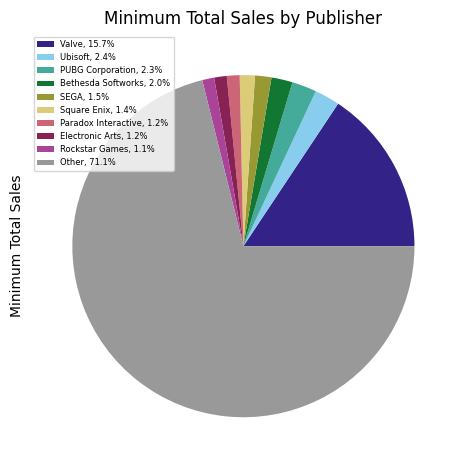

```python
# take the top 9 publishers and group the rest into "Other"
top_9_publishers = pd.Series(data=publisher_sales[:9])
top_9_publishers.at["Other"] = publisher_sales[10:].sum()
total_sales = top_9_publishers.sum()
color = ['#332288', '#88CCEE', '#44AA99', '#117733', '#999933', '#DDCC77', '#CC6677', '#882255', '#AA4499', '#999999'] # to help with colorblind friendliness
labels = [f'{l}, {s:0.1f}%' for l, s in zip(top_9_publishers.index, top_9_publishers.apply(lambda x: x / total_sales * 100))]
plt.pie(top_9_publishers, colors=color)
plt.title("Minimum Total Sales by Publisher")
plt.legend(labels, prop={'size': 6}, loc="best")
plt.ylabel("Minimum Total Sales")
plt.tight_layout()
```

**Let's do an ANOVA test on the top 9 publishers.**

```python
# find the names of the top 20 publishers who have the most sales
top_9_publishers_names = publisher_sales.head(9).index

# get the respective rating proportion groups for each publisher
grouped_proportions = df2["pos_rating_proportion"].groupby(df2["publisher"])
top_9_groups = [group for name, group in grouped_proportions if name in top_9_publishers_names]

# ANOVA test
print("P-value: {}".format(scipy.stats.f_oneway(*top_9_groups)[1]))
```

```
P-value: 2.269163519775008e-06
```

**Let's also plot the mean rating proportions to get a better understanding of the difference between the publishers.**

[figure not shown]

```python
# get the mean of the group proportions and filter by the top publishers
grouped_proportions.mean().filter(items=top_9_publishers_names).sort_values(ascending=False).plot(kind="bar", ylabel = "positive rating proportion")
plt.xticks(rotation=90)
plt.yticks([0, 0.25, 0.5, 0.75, 1])
plt.title("Mean Positive Rating Proportion for Top 20 Publishers by Sales")
plt.show()
```

**Since the p-value is below the significance value of 0.05, we can conclude that there is a statistically significant difference between the top 9 Steam game publishers' mean positive rating proportions. This suggests that while all 9 publishers have a large player base, not all of the publishers have the same ratings for their franchises. This means that the name of the publisher matters when it comes to the average rating of a game. We were interested in testing this hypothesis because we wanted to see whether certain publishers had generally higher percentage of positive game reviews than others. This test tells us that we need to incorporate the publisher into our predictive ML model.**

### Summary Stat 2 (Chi-Squared)

**Next, let's find the ratio of price category to category of success measured by number of sales.**

**Let's first explore the price data for outliers by using a boxplot.**

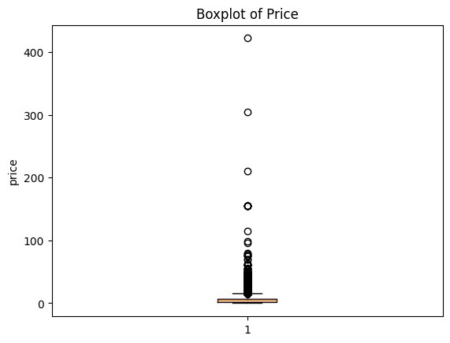

```python
plt.boxplot(df2['price'])
plt.ylabel('price')
plt.title("Boxplot of Price")
```

**There are quite a few outliers!**

**Let's use quantiles since it is less subject to outlier skew.**

```python
df2['price'].quantile(q=[0.2,0.4,0.6,0.8])
```

```
0.2    0.79
0.4    3.19
0.6    5.19
0.8    9.29
Name: price, dtype: float64
```

**Since the price data can be broken down into reasonable quantiles, we can create categories using them.**

```python
def split_price_categories(price):
    if price <= 0.79:
        return "Low"
    elif price <= 3.19:
        return "Medium-Low"
    elif price <= 5.19:
        return "Medium"
    elif price <= 9.29:
        return "Medium-High"
    else:
        return "High"

df2["price_categories"] = df2['price'].apply(split_price_categories)
```

**We can then explore the sales data distribution.**

```python
# now lets examine how the sales data is distributed
df2['sales'].value_counts()
```

```
sales
[0, 20000]                18595
[20000, 50000]             3059
[50000, 100000]            1695
[100000, 200000]           1386
[200000, 500000]           1272
[500000, 1000000]           513
[1000000, 2000000]          288
[2000000, 5000000]          193
[5000000, 10000000]          46
[10000000, 20000000]         21
[20000000, 50000000]          3
[50000000, 100000000]         2
[100000000, 200000000]        1
Name: count, dtype: int64
```

**In this step, instead of dealing with a numerical range for the sales, we convert each to a category. This will be helpful for our ML model later.**

**Sales categories:**

- **0-50,000 -> Low**
- **50,000-200,000 -> Medium-Low**
- **200,000-2,000,000 -> Medium**
- **2,000,000-20,000,000 -> Medium-High**
- **20,000,000+ -> High**

**A similar conversion is performed over the price for each game.**

```python
def split_sales_categories(numsales):
    if numsales == 0 or numsales == 20000:
        return "Low"
    elif numsales == 50000 or numsales == 100000:
        return "Medium-Low"
    elif numsales == 200000 or numsales == 500000 or numsales== 1000000:
        return "Medium"
    elif numsales == 2000000 or numsales == 5000000 or numsales == 10000000:
        return "Medium-High"
    else:
        return "High"

df2["sales_categories"] = df2['minimum_sales'].apply(split_sales_categories)
```

**Now we can create a crosstab of our two variables for our chi-squared test.**

```python
# create crosstab to apply chi-square test
sidenames = ['Low', 'Medium-Low', 'Medium', 'Medium-High', 'High']

cont_table = pd.crosstab(df2["price_categories"], df2["sales_categories"])
cont_table = cont_table.reindex(sidenames, axis="columns")
cont_table = cont_table.reindex(sidenames, axis="rows")
cont_table
```

| sales_categories price_categories | Low | Medium-Low | Medium | Medium-High | High |
| --- | --- | --- | --- | --- | --- |
| Low | 4060 | 789 | 548 | 89 | 5 |
| Medium-Low | 4832 | 422 | 186 | 3 | 0 |
| Medium | 4620 | 504 | 213 | 13 | 0 |
| Medium-High | 4410 | 603 | 379 | 36 | 0 |
| High | 3732 | 763 | 747 | 119 | 1 |

**We can now run the chi-squared test.**

```python
_, p, _, _ = scipy.stats.chi2_contingency(cont_table)
print("P-Value = " + str(p))
```

```
P-Value = 7.110877223565093e-222
```

**We should also plot the data to get a better idea of the category distribution.**

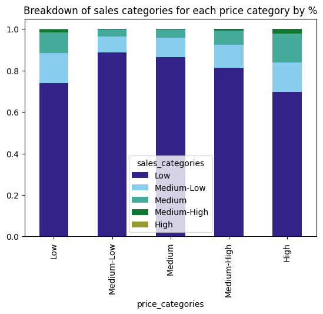

```python
# normalize the data for plotting
cont_table = pd.crosstab(df2["price_categories"], df2["sales_categories"], normalize='index') #we dont want to use normalized data for plotting since that will mess up the calc.
cont_table = cont_table.reindex(sidenames, axis="columns")
cont_table = cont_table.reindex(sidenames, axis="rows")

cont_table.plot(kind='bar', stacked=True, title="Breakdown of sales categories for each price category by %", color=color)
```

**Since our p value is below the significance value of 0.05, we can conclude from this test that there is a relationship between the price category of a game and how many owners it has. We can see from the graph that generally, games with Low and High prices have a higher percentage of higher ownership. We are interested in this conclusion since we wanted to see how pricing of a game impacts how successful it will be as measured by total sales**

### Summary Stat 3 (Pearson Correlation Coefficient)

**Finally, we will use Pearson Correlation to find if there is a correlation between the median playtime of the game and its positive rating proportion.**

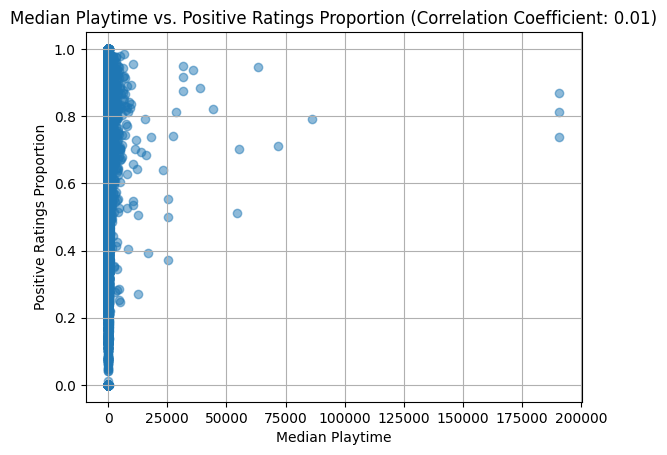

```
Pearson Correlation Coefficient (r): 0.013231710785338947
```

```python
# find correlation between median playtime and pos rating proportion using pearson correlation

correlation_coefficient = df2['median_playtime'].corr(df2['pos_rating_proportion'])

plt.scatter(df2['median_playtime'], df2['pos_rating_proportion'], alpha=0.5)
plt.xlabel('Median Playtime')
plt.ylabel('Positive Ratings Proportion')
plt.title(f'Median Playtime vs. Positive Ratings Proportion (Correlation Coefficient: {correlation_coefficient:.2f})')
plt.grid(True)
plt.show()

print("Pearson Correlation Coefficient (r):" , correlation_coefficient)
```

**For this test, we wanted to see if there was possibly a correlation between the positive reception of a game and its median playtime. As a base assumption, we assumed that a better reception would lead to more hours and a worse reception less hours. This would make sense, as a more quality game can lead to people wanting to play it more. As the graph/coefficient shows, there is little correlation between them. The Pearson correlation coefficient test was chosen as it nicely highlights the correlation (or lack thereof) between the two variables.**

### Data Analysis Conclusions

**From our third test, we can conclude that the reception of a game does not necessarily impact its median playtime. For our algorithm, we can make the playtime of a game have less weight in determining its reception.**

## Primary Analysis: Machine Learning Model

**Now for our model.**

**As we explained before, we want to use a classification model to predict a Steam game's sales. For this project, we choose to use an ensemble of decision trees. To make this process easier, we are using a framework developed by Microsoft called [LightGBM](https://lightgbm.readthedocs.io/en/latest/index.html). We choose this specifically since it has better support for categorical features than scikitlearn or XGBoost.**

**Now our data as is isn't compatible with training (lists, non-ascii characters, etc.), so we need to do some cleaning. After cleaning, we perform [One Hot Encoding](https://lightgbm.readthedocs.io/en/latest/index.html) on the platforms, categories, and tags by splitting apart their respective lists. This step really fattens up our dataframe!**

```python
# replace all non-ASCII strings with "Other". This doesnt make a difference since we don't care about the publisher's exact name.
def clean_ascii(x):
    np.set_printoptions(threshold=sys.maxsize)
    if (not str(x).isascii()):
        return "Other"
    return x

# replace all JSON special characters with "_"
def rid_json(x):
    return re.sub('[^A-Za-z0-9_]+', '_', str(x))

# apply both functions to publisher and developer columns
df2["publisher"] = df2["publisher"].apply(clean_ascii)
df2["developer"] = df2["developer"].apply(clean_ascii)
df2["publisher"] = df2["publisher"].apply(rid_json)
df2["developer"] = df2["developer"].apply(rid_json)

# manually apply "Category" and "Tag" prefix to category and tag columns since
# one hot encoding doesn't automatically parse semi-colon-separated lists
df2["categories"] = df2["categories"].apply(lambda x: ["Category " + str(y) for y in x])
df2["steamspy_tags"] = df2["steamspy_tags"].apply(lambda x: ["Tag " + str(y) for y in x])

# perform one-hot encoding on platforms, categories, and steamspy_tags columns
df2 = (df2.join(df2.pop('platforms')
              .apply('|'.join)
              .str.get_dummies())
      )
df2 = (df2.join(df2.pop('categories')
              .apply('|'.join)
              .str.get_dummies())
      )
df2 = (df2.join(df2.pop('steamspy_tags')
              .apply('|'.join)
              .str.get_dummies())
      )
df2
```

|  | release_date | developer | publisher | positive_ratings | negative_ratings | average_playtime | median_playtime | sales | price | total_ratings | ... | Tag Warhammer 40K | Tag Web Publishing | Tag Werewolves | Tag Western | Tag Word Game | Tag World War I | Tag World War II | Tag Wrestling | Tag Zombies | Tag e-sports |
| --- | --- | --- | --- | --- | --- | --- | --- | --- | --- | --- | --- | --- | --- | --- | --- | --- | --- | --- | --- | --- | --- |
| 0 | 2000-11-01 | Valve | Valve | 124534 | 3339 | 17612 | 317 | [10000000, 20000000] | 7.19 | 127873 | ... | 0 | 0 | 0 | 0 | 0 | 0 | 0 | 0 | 0 | 0 |
| 1 | 1999-04-01 | Valve | Valve | 3318 | 633 | 277 | 62 | [5000000, 10000000] | 3.99 | 3951 | ... | 0 | 0 | 0 | 0 | 0 | 0 | 0 | 0 | 0 | 0 |
| 2 | 2003-05-01 | Valve | Valve | 3416 | 398 | 187 | 34 | [5000000, 10000000] | 3.99 | 3814 | ... | 0 | 0 | 0 | 0 | 0 | 0 | 1 | 0 | 0 | 0 |
| 3 | 2001-06-01 | Valve | Valve | 1273 | 267 | 258 | 184 | [5000000, 10000000] | 3.99 | 1540 | ... | 0 | 0 | 0 | 0 | 0 | 0 | 0 | 0 | 0 | 0 |
| 4 | 1999-11-01 | Gearbox_Software | Valve | 5250 | 288 | 624 | 415 | [5000000, 10000000] | 3.99 | 5538 | ... | 0 | 0 | 0 | 0 | 0 | 0 | 0 | 0 | 0 | 0 |
| ... | ... | ... | ... | ... | ... | ... | ... | ... | ... | ... | ... | ... | ... | ... | ... | ... | ... | ... | ... | ... | ... |
| 27069 | 2019-04-24 | SHEN_JIAWEI | SHEN_JIAWEI | 3 | 0 | 0 | 0 | [0, 20000] | 2.09 | 3 | ... | 0 | 0 | 0 | 0 | 0 | 0 | 0 | 0 | 0 | 0 |
| 27070 | 2019-04-23 | Semyon_Maximov | BekkerDev_Studio | 8 | 1 | 0 | 0 | [0, 20000] | 1.69 | 9 | ... | 0 | 0 | 0 | 0 | 0 | 0 | 0 | 0 | 0 | 0 |
| 27071 | 2019-04-24 | EntwicklerX | EntwicklerX | 0 | 1 | 0 | 0 | [0, 20000] | 3.99 | 1 | ... | 0 | 0 | 0 | 0 | 0 | 0 | 0 | 0 | 0 | 0 |
| 27072 | 2019-04-17 | Yustas_Game_Studio | Alawar_Entertainment | 2 | 0 | 0 | 0 | [0, 20000] | 5.19 | 2 | ... | 0 | 0 | 0 | 0 | 0 | 0 | 0 | 0 | 0 | 0 |
| 27073 | 2019-04-24 | Adept_Studios_GD | Alawar_Entertainment | 4 | 0 | 0 | 0 | [0, 20000] | 5.19 | 4 | ... | 0 | 0 | 0 | 0 | 0 | 0 | 0 | 0 | 0 | 0 |

27074 rows × 387 columns

**We perform One Hot Encoding on the developers and publishers as well.**

**Word to the Wise: this next step is incredibly memory intensive and results in over 30,000 columns since each publisher and developer gets its own column. During our testing, this whole process took over 19GB in memory, and crashed google collab. We had to use an AWS EC2 instance with 32gb of ram to get this to work properly. In big datasets, issues like these are common. That's why big tech companies invest millions into building server farms with massive amounts of compute to handle data analysis.**

```python
df2= pd.get_dummies(df2, columns=['developer', 'publisher'])
df2
```

|  | release_date | positive_ratings | negative_ratings | average_playtime | median_playtime | sales | price | total_ratings | pos_rating_proportion | pos_rating_proportion_categories | ... | publisher_yyrGames | publisher_zachs123456 | publisher_zedzag | publisher_zemaGamez | publisher_zerofiftyone | publisher_zeroplaystone | publisher_zha7 | publisher_zhangwenlu | publisher_znq_ | publisher_zoocros |
| --- | --- | --- | --- | --- | --- | --- | --- | --- | --- | --- | --- | --- | --- | --- | --- | --- | --- | --- | --- | --- | --- |
| 0 | 2000-11-01 | 124534 | 3339 | 17612 | 317 | [10000000, 20000000] | 7.19 | 127873 | 0.973888 | 90.0% to 100.0% | ... | False | False | False | False | False | False | False | False | False | False |
| 1 | 1999-04-01 | 3318 | 633 | 277 | 62 | [5000000, 10000000] | 3.99 | 3951 | 0.839787 | 80.0% to 90.0% | ... | False | False | False | False | False | False | False | False | False | False |
| 2 | 2003-05-01 | 3416 | 398 | 187 | 34 | [5000000, 10000000] | 3.99 | 3814 | 0.895648 | 80.0% to 90.0% | ... | False | False | False | False | False | False | False | False | False | False |
| 3 | 2001-06-01 | 1273 | 267 | 258 | 184 | [5000000, 10000000] | 3.99 | 1540 | 0.826623 | 80.0% to 90.0% | ... | False | False | False | False | False | False | False | False | False | False |
| 4 | 1999-11-01 | 5250 | 288 | 624 | 415 | [5000000, 10000000] | 3.99 | 5538 | 0.947996 | 90.0% to 100.0% | ... | False | False | False | False | False | False | False | False | False | False |
| ... | ... | ... | ... | ... | ... | ... | ... | ... | ... | ... | ... | ... | ... | ... | ... | ... | ... | ... | ... | ... | ... |
| 27069 | 2019-04-24 | 3 | 0 | 0 | 0 | [0, 20000] | 2.09 | 3 | 1.000000 | 90.0% to 100.0% | ... | False | False | False | False | False | False | False | False | False | False |
| 27070 | 2019-04-23 | 8 | 1 | 0 | 0 | [0, 20000] | 1.69 | 9 | 0.888889 | 80.0% to 90.0% | ... | False | False | False | False | False | False | False | False | False | False |
| 27071 | 2019-04-24 | 0 | 1 | 0 | 0 | [0, 20000] | 3.99 | 1 | 0.000000 | 0.0% to 10.0% | ... | False | False | False | False | False | False | False | False | False | False |
| 27072 | 2019-04-17 | 2 | 0 | 0 | 0 | [0, 20000] | 5.19 | 2 | 1.000000 | 90.0% to 100.0% | ... | False | False | False | False | False | False | False | False | False | False |
| 27073 | 2019-04-24 | 4 | 0 | 0 | 0 | [0, 20000] | 5.19 | 4 | 1.000000 | 90.0% to 100.0% | ... | False | False | False | False | False | False | False | False | False | False |

27074 rows × 30986 columns

**To prepare the dataframe for model analysis, we'll drop columns that have redundant information. We want to reduce the dimensionality while still keeping important data. Most of these columns were also used only as a temporary means for our data analysis.**

```python
df2 = df2.drop(columns=["release_date", "positive_ratings", "negative_ratings"
                        , "sales", "pos_rating_proportion_categories", "minimum_sales"
                        , "maximum_sales", "price_categories"])
df2
```

|  | average_playtime | median_playtime | price | total_ratings | pos_rating_proportion | sales_categories | Linux | Mac | Windows | Category Captions available | ... | publisher_yyrGames | publisher_zachs123456 | publisher_zedzag | publisher_zemaGamez | publisher_zerofiftyone | publisher_zeroplaystone | publisher_zha7 | publisher_zhangwenlu | publisher_znq_ | publisher_zoocros |
| --- | --- | --- | --- | --- | --- | --- | --- | --- | --- | --- | --- | --- | --- | --- | --- | --- | --- | --- | --- | --- | --- |
| 0 | 17612 | 317 | 7.19 | 127873 | 0.973888 | Medium-High | 1 | 1 | 1 | 0 | ... | False | False | False | False | False | False | False | False | False | False |
| 1 | 277 | 62 | 3.99 | 3951 | 0.839787 | Medium-High | 1 | 1 | 1 | 0 | ... | False | False | False | False | False | False | False | False | False | False |
| 2 | 187 | 34 | 3.99 | 3814 | 0.895648 | Medium-High | 1 | 1 | 1 | 0 | ... | False | False | False | False | False | False | False | False | False | False |
| 3 | 258 | 184 | 3.99 | 1540 | 0.826623 | Medium-High | 1 | 1 | 1 | 0 | ... | False | False | False | False | False | False | False | False | False | False |
| 4 | 624 | 415 | 3.99 | 5538 | 0.947996 | Medium-High | 1 | 1 | 1 | 0 | ... | False | False | False | False | False | False | False | False | False | False |
| ... | ... | ... | ... | ... | ... | ... | ... | ... | ... | ... | ... | ... | ... | ... | ... | ... | ... | ... | ... | ... | ... |
| 27069 | 0 | 0 | 2.09 | 3 | 1.000000 | Low | 0 | 0 | 1 | 0 | ... | False | False | False | False | False | False | False | False | False | False |
| 27070 | 0 | 0 | 1.69 | 9 | 0.888889 | Low | 0 | 0 | 1 | 0 | ... | False | False | False | False | False | False | False | False | False | False |
| 27071 | 0 | 0 | 3.99 | 1 | 0.000000 | Low | 0 | 0 | 1 | 0 | ... | False | False | False | False | False | False | False | False | False | False |
| 27072 | 0 | 0 | 5.19 | 2 | 1.000000 | Low | 0 | 1 | 1 | 0 | ... | False | False | False | False | False | False | False | False | False | False |
| 27073 | 0 | 0 | 5.19 | 4 | 1.000000 | Low | 0 | 1 | 1 | 0 | ... | False | False | False | False | False | False | False | False | False | False |

27074 rows × 30978 columns

**Because we are trying to predict categorical data with LightGBM, we must first translate each category to a number.**

**Then we perform a standard train/test split to get our training and test sets.**

```python
y = df2['sales_categories'].copy(deep=True).map({"Low": 0, "Medium-Low": 1, "Medium": 2, "Medium-High": 3, "High": 4})

X = df2.iloc[:, 1:]
X = X.drop(columns=["sales_categories"])

X[['average_playtime', 'median_playtime', "price", "pos_rating_proportion", "total_ratings"]] = StandardScaler().fit_transform(df2[['average_playtime',
                                                                                                                                    'median_playtime',
                                                                                                                                    "price",
                                                                                                                                    "pos_rating_proportion",
                                                                                                                                    "total_ratings"]])

X_train, X_test, y_train, y_test = train_test_split(X, y, test_size = 0.2, random_state = 0)
```

**Now for the actual training!**

**As mentioned earlier, we chose LightGBM for our model as it has a fairly robust set of features, including allowing for categorical features and using an ensemble tecnique called gradient boosting by default. It's also dead simple to use and train with, not requiring much tuning.**

**For LightGBM, we must provide parameters that specify how we want our model to train.**

```python
PARAMS = {
    "objective": "multiclass", # we have multiple categories we're trying to predict
    "num_class": 5, # specifically, 5 classes
    "num_iterations": 500,
    "learning_rate": 0.05,
    "num_leaves": 2048, # specify maximum number of leaves in the model
    "max_depth": 15, # specify maximum model depth
    "min_data_in_leaf": 50,
    "verbose": -1,
}

x_train = lgb.Dataset(X_train, y_train)
model = lgb.train(PARAMS, x_train)
```

**Now that our model has finished training, let's print out its classification report!**

**The predict function returns the probabilities for each category, so we can take the highest one as the categorical prediction.**

```python
y_pred=model.predict(X_test)

y_pred = np.argmax(y_pred, axis=1)
print(classification_report(y_test, y_pred))
```

```
              precision    recall  f1-score   support

           0       0.96      0.97      0.97      4345
           1       0.63      0.61      0.62       610
           2       0.77      0.68      0.72       410
           3       0.69      0.63      0.66        49
           4       1.00      1.00      1.00         1

    accuracy                           0.91      5415
   macro avg       0.81      0.78      0.79      5415
weighted avg       0.90      0.91      0.91      5415
```

**Perhaps we can do better? Let's change some of the hyperparameters to see if it will affect the scores.**

```python
PARAMS = {
    "objective": "multiclass", # we have multiple categories we're trying to predict
    "num_class": 5, # specifically, 5 classes
    "num_iterations": 1000,
    "learning_rate": 0.05,
    "num_leaves": 16384, # specify maximum number of leaves in the model
    "max_depth": 100, # specify maximum model depth
    "min_data_in_leaf": 50,
    "verbose": -1,
}

x_train = lgb.Dataset(X_train, y_train)
model2 = lgb.train(PARAMS, x_train)
```

```python
y_pred=model2.predict(X_test)

y_pred = np.argmax(y_pred, axis=1)
print(classification_report(y_test, y_pred))
```

```
              precision    recall  f1-score   support

           0       0.96      0.97      0.97      4345
           1       0.63      0.59      0.61       610
           2       0.77      0.70      0.74       410
           3       0.80      0.65      0.72        49
           4       1.00      1.00      1.00         1

    accuracy                           0.91      5415
   macro avg       0.83      0.78      0.81      5415
weighted avg       0.90      0.91      0.91      5415
```

**As we can see, not much actually seems to change. But, the scores for class 3 seems to be making an improvement. This could potentially be a result of overfitting, though, so we would have to be careful with that. However for now, this model with these parameters looks promising.**.

## Model Analysis and Visualization

**Let's first see a confusion matrix on how the predicisions line up with the actual values for different categories**

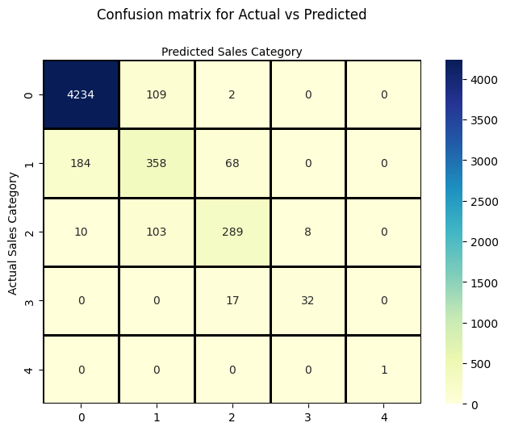

```python
conf_matrix = confusion_matrix(y_test, y_pred)

#  refrence: https://www.kaggle.com/code/aakritsinghal/logistic-regression-visualisation

class_names = ["Low", "Medium-Low", "Medium", "Medium-High", "High"]

fig, ax = plt.subplots()

tick_marks = np.arange(len(class_names))

plt.xticks(tick_marks, class_names)
plt.yticks(tick_marks, class_names)


ses.heatmap(conf_matrix, annot=True, cmap="YlGnBu" ,fmt='g',  linewidth=1, linecolor="black", ax=ax)
ax.xaxis.set_label_position("top")

plt.tight_layout()
plt.title('Confusion matrix for Actual vs Predicted', y = 1.1)

plt.xlabel("Predicted Sales Category")
plt.ylabel("Actual Sales Category")
```

**From this, we can see that generally, the majority of the predictions for the class correspond with the correct accuracy.**

**Let's also visualize the accuracy within each sales category.**

```
<BarContainer object of 5 artists>
```

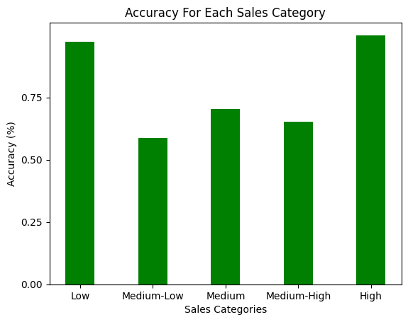

```python
matrix = confusion_matrix(y_test, y_pred)
matrix = matrix.diagonal()/matrix.sum(axis=1)

plt.xlabel('Sales Categories')
plt.ylabel('Accuracy (%)')
plt.yticks(np.arange(0, 1, step=0.25))
# plt.yticks(.2505[0,0.25,0.5,0.75,1], ["0%", "25%", "50%", "75%", "100%", "100%", "100%", "100%:"])
plt.title("Accuracy For Each Sales Category")
plt.bar(["Low", "Medium-Low", "Medium", "Medium-High", "High"], matrix, color = "green", width = .4)
```

**Let's next look at the top 10 most important features that impact the sales category.**

```python
feature_imp = pd.DataFrame({'Value':model.feature_importance(),'Feature':X.columns})
feature_imp.sort_values(by="Value", ascending=False).head(10)
```

|  | Value | Feature |
| --- | --- | --- |
| 2 | 59372 | total_ratings |
| 3 | 51547 | pos_rating_proportion |
| 1 | 33101 | price |
| 0 | 23980 | median_playtime |
| 30976 | 15294 | average_playtime |
| 27 | 5512 | Category Steam Achievements |
| 175 | 4920 | Tag Indie |
| 30 | 4674 | Category Steam Trading Cards |
| 49 | 3658 | Tag Action |
| 5 | 2891 | Mac |

**We can see that the top 5 features the model selected are total ratings, positive rating proportion, price, average playtime, and median playtime. Let's visualize them and see if we can analyze why the model chose these as important features.**

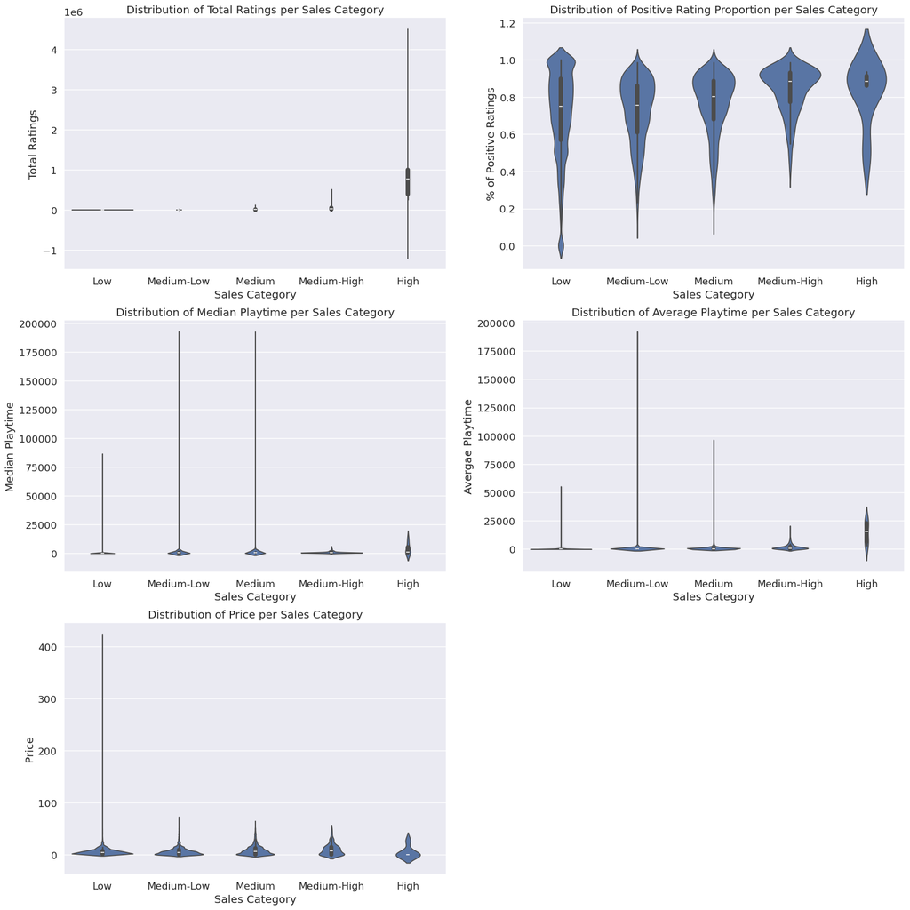

```python
ses.set(font_scale=1.2)

fig = plt.figure(figsize=(20,35))

fig.add_subplot(5, 2, 1)
ses.violinplot(data=df2, x="sales_categories", y="total_ratings", order=["Low", "Medium-Low", "Medium", "Medium-High", "High"]).set(xlabel="Sales Category", ylabel="Total Ratings")
plt.title("Distribution of Total Ratings per Sales Category")

fig.add_subplot(5, 2, 2)
ses.violinplot(data=df2, x="sales_categories", y="pos_rating_proportion", order=["Low", "Medium-Low", "Medium", "Medium-High", "High"]).set(xlabel="Sales Category", ylabel="% of Positive Ratings")
plt.title("Distribution of Positive Rating Proportion per Sales Category")

fig.add_subplot(5, 2, 3)
ses.violinplot(data=df2, x="sales_categories", y="median_playtime", order=["Low", "Medium-Low", "Medium", "Medium-High", "High"]).set(xlabel="Sales Category", ylabel="Median Playtime")
plt.title("Distribution of Median Playtime per Sales Category")

fig.add_subplot(5, 2, 4)
ses.violinplot(data=df2, x="sales_categories", y="average_playtime", order=["Low", "Medium-Low", "Medium", "Medium-High", "High"]).set(xlabel="Sales Category", ylabel="Avergae Playtime")
plt.title("Distribution of Average Playtime per Sales Category")

fig.add_subplot(5, 2, 5)
ses.violinplot(data=df2, x="sales_categories", y="price", order=["Low", "Medium-Low", "Medium", "Medium-High", "High"]).set(xlabel="Sales Category", ylabel="Price")
plt.title("Distribution of Price per Sales Category")
```

**Wow. Those sure do look glorious. Seaborn for the win!**

**These new plots we are using are violin plots. Essentially, they allow us to see a box and whisker distribution and density curves for all the data that falls into a certain category, adding another layer of dimensionality to the data. Where you see total ratings going below -1 or % pos ratings go above 1.0 is an artifact of the violin plot**

**Now, let's take a second to analyze these results and see why they make sense, and why our model chose them as the more important features.**

**In our first plot of total ratings per sales category, we see that games with more ratings tend to have a higher sales category. This makes sense: the more people who buy a game, the more users who can/do leave a review.**

**Our second plot of % of positive reviews per sales category shows something interesting. Although the medians for all categories for % positive ratings are very pretty similar, the higher sales categories seem to have slightly higher maximum percentages and it seems like most of the data is closer to the upper end of the percentage scale. Although a human might miss these miniscule differences, the model is able to use these fluctuations differences to make an informed decision. Once again, this makes sense: games with higher percentages of positive ratings means people liked the game, and therefore it would make sense that this feature has a high importance in determining overall success.**

**Our third and fourth plots show the median and average playtime per sales category respectively. Intuitively, you would expect games with a higher playtime to be more popular, but at first look, the plots seem to show that games with medium or medium low sales have the most amount of playtime. This is where the violin plot shines! We can look at the distribution (density) of the data in each category and see that the games in the high sales category have less outliers and a greater density towards the maximum of the distribution. Once again, this makes sense: games with higher playtimes means people liked the game, and therefore it would make sense that this feature has a high importance in determining overall success.**

**Our final plot, price versus sales category, also shows something interesting. It looks like games that have high sales have a lower median than the rest. In the context of the tree, it makes sense that price is an important feature to determining sales since cheaper games are more affordable to players.**

**Phew. That was a lot. Now that we understand why our ensemble chose these categories, time to visualize our decision tree in all its glory!**

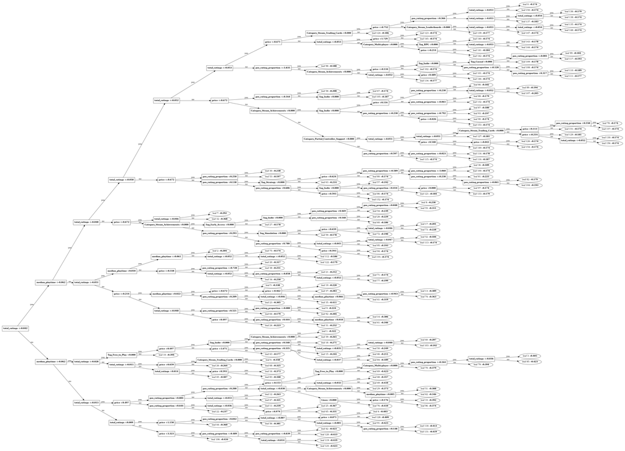

```python
lgb.plot_tree(model, figsize=(50,50))
```

```python
lgb.create_tree_digraph(model, example_case=X.iloc[[2]], show_info=['internal_value'])
```

[figure not shown]

**An awesome feature of decision trees is the ability to see exactly how the model is making its decision, unlike something like neural networks which are more or less a black box. It's super interesting to follow the path of an example.**

## Insights and Conclusions

**Our model's accuracy also supports our hypothesis that there are indeed factors that have an impact on how many copies of a game are sold. Based on the feature importance within our model, it seems that the total number of ratings and the positive rating proportion have the largest impact on the number of owners. This makes sense, as a game with more reviews most likely means that it has been purchased more. A higher positivity percentage combined with the number of total ratings would also imply that potential buyers would be more willing to purchase, as the game is highly reviewed by many people.**

**To use our model for new games, we would have to manually put in dummy values for reviews or playtime to simulate a game being on the store. An example of these values could be the median or means of those features. Another follow-up project could try creating a model while dropping these features from the dataset to see if sales can still be predicted accurately.**

**Since the data was also scraped around May 2019, it would be interesting to see if the model is still accurate when assessing newer games. It would be interesting to see how the model assesses groundbreaking games such as Elden Ring, Baldur's Gate 3, Lethal Company, or Helldivers 2.**

**As for the process as a whole, one key takeaway is the importance of data analysis and cleaning. At the start, our dataframe wasn't easy to work with, so transforming the data into a nicer format was a necessary change. Certain parts of the dataframe were difficult to work with, such as the semicolon separated list, showing the impact data collection can have on data analysis. It's good to keep in mind what you want to do with the data you collect before actually gathering it to prevent more work down the line.**

## Helpful Links

One Hot Encoding - https://www.geeksforgeeks.org/ml-one-hot-encoding/#

Pandas Cheat Sheet - https://www.datacamp.com/cheat-sheet/pandas-cheat-sheet-for-data-science-in-python

Choosing the Right Statistical Test - https://www.scribbr.com/statistics/statistical-tests/

Plotting with Matplotlib - https://matplotlib.org/stable/tutorials/pyplot.html

LightGBM QuickStart - https://lightgbm.readthedocs.io/en/stable/Quick-Start.html